# Systems Analysis

author: Brian High date: 2014-12-01 transition: fade

## Research Computing and Data Management

http://github.com/brianhigh/research-computing

This work is licensed under a [Creative Commons Attribution-ShareAlike 4.0 International License](http://creativecommons.org/licenses/by-sa/4.0/).

# Systems Development Life Cycle

We will take a closer look at the **[systems analysis](http://en.wikipedia.org/wiki/Systems_analysis)** phase.

- [Planning](http://en.wikipedia.org/wiki/Systems_development_life_cycle#System_investigation) ([feasibility study](http://en.wikipedia.org/wiki/Feasibility_study))
- **[Analysis](http://en.wikipedia.org/wiki/Systems_development_life_cycle#System_analysis)**
- Design
- [Implementation](http://en.wikipedia.org/wiki/Implementation#Information_Technology_.28IT.29)
- [Maintenance](http://en.wikipedia.org/wiki/Software_maintenance)

Source: [Wikipedia](http://en.wikipedia.org/wiki/Systems_development_life_cycle#Phases), [CC BY-SA 3.0](http://en.wikipedia.org/wiki/Wikipedia:Text_of_Creative_Commons_Attribution-ShareAlike_3.0_Unported_License)

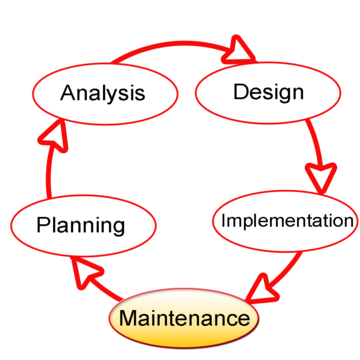

Source: [Dzonatas, CC BY-SA 3.0, (Wikimedia)](http://commons.wikimedia.org/wiki/File:SDLC-Maintenance-Highlighted.png)

# What will you need?

A **primary goal** of this course is to help you develop your skills in *[requirements analysis](http://en.wikipedia.org/wiki/Requirements_analysis)*.

[Requirements analysis](http://en.wikipedia.org/wiki/Requirements_analysis) is an **essential component** of *[Systems analysis](http://en.wikipedia.org/wiki/Systems_analysis)*.

[Systems analysis](http://en.wikipedia.org/wiki/Systems_analysis) helps you **clarify your project needs** and **plan ahead** in order to obtain and allocate **critical resources**.

> If you don’t *know* what you *need*, how can you *ask* for it?

# Systems Analysis

After completing an initial [feasibility study](http://en.wikipedia.org/wiki/Feasibility_study) to “determine if creating a new or improved system is a viable solution”, proposing the project, and gaining approval from [stakeholders](http://en.wikipedia.org/wiki/Project_stakeholder), you may then conduct a [systems analysis](http://en.wikipedia.org/wiki/Systems_analysis).

[Systems analysis](http://en.wikipedia.org/wiki/Systems_analysis) will involve “[breaking down](http://en.wikipedia.org/wiki/Work_breakdown_structure) the system in different pieces to analyze the situation, **analyzing project goals**, breaking down what needs to be created and attempting to **engage users** so that **[definite requirements](http://en.wikipedia.org/wiki/Requirements_analysis)** can be defined.”

Source: [Wikipedia](http://en.wikipedia.org/wiki/Systems_development_life_cycle#System_investigation), [CC BY-SA 3.0](http://en.wikipedia.org/wiki/Wikipedia:Text_of_Creative_Commons_Attribution-ShareAlike_3.0_Unported_License)

# Systems Analysis Definition

*analysis* = “to take apart”<sup>1</sup>

> [Systems analysis](http://en.wikipedia.org/wiki/Systems_analysis) is a problem solving technique that decomposes a system into its component pieces for the purpose of the studying how well those component parts work and interact to accomplish their purpose.<sup>2</sup>

We will accomplish this analysis by working through a series of [five phases](http://en.wikipedia.org/wiki/Systems_analysis#Information_technology).

1. Source: [Wikipedia](http://en.wikipedia.org/wiki/Systems_analysis), [CC BY-SA 3.0](http://en.wikipedia.org/wiki/Wikipedia:Text_of_Creative_Commons_Attribution-ShareAlike_3.0_Unported_License) 2. Source: *Systems Analysis and Design for the Global Enterprise 7th ed.*, by Lonnie D. Bentley, as quoted by [Wikipedia](http://en.wikipedia.org/wiki/Systems_analysis)

# Systems Analysis Phases

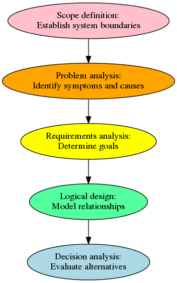

1. [Scope definition](http://en.wikipedia.org/wiki/Scope_%28project_management%29): Establish system boundaries
2. [Problem analysis](http://en.wikipedia.org/wiki/Problem_statement): Identify symptoms and causes
3. [Requirements analysis](http://en.wikipedia.org/wiki/Requirements_analysis): Determine goals
4. [Logical design](http://en.wikipedia.org/wiki/Systems_design#Logical_design): Model relationships
5. [Decision analysis](http://en.wikipedia.org/wiki/Decision_analysis): Evaluate alternatives

Source: [Wikipedia](http://en.wikipedia.org/wiki/Systems_analysis#Information_technology), [CC BY-SA 3.0](http://en.wikipedia.org/wiki/Wikipedia:Text_of_Creative_Commons_Attribution-ShareAlike_3.0_Unported_License)

# Scope Definition

> **Scope** involves *getting information* required to start a project, and the *features* the product would have that would meet its *stakeholders requirements*.
- **Project Scope**: *work to be done*
- **Product Scope**: *desired features and functions*

> **Scope creep** is […] the *incremental expansion* of the scope of a project […], while nevertheless *failing to adjust* schedule and budget.

Source: [Wikipedia](http://en.wikipedia.org/wiki/Scope_%28project_management%29), [CC BY-SA 3.0](http://en.wikipedia.org/wiki/Wikipedia:Text_of_Creative_Commons_Attribution-ShareAlike_3.0_Unported_License)

# Problem Analysis

- Define and clarify the problem
- Determine the problem’s importance
- Assess the feasibility of solving the problem
- Consider any negative impacts (unintended consequences)
- Prioritize problems to solve (bottlenecks? low-hanging fruit?)
- Answer: *what*, *why*, *who*, *when*, *where*, and *how much*?
- Find **causes** (especially [root cause](http://en.wikipedia.org/wiki/Root_cause_analysis)) and **symptoms** (effects)

Source: [Jenette Nagy, Kansas University, CC BY-NC-SA 3.0 US](http://ctb.ku.edu/en/table-of-contents/analyze/analyze-community-problems-and-solutions/define-analyze-problem/main)

# Requirements Analysis

- [Elicit, Analyze, and Record (EAR)](http://en.wikipedia.org/wiki/Requirements_analysis#Overview):
- System and project [requirements](http://en.wikipedia.org/wiki/Requirements_analysis)
- Further elucidate:
- [Measurable goals](http://en.wikipedia.org/wiki/Requirements_analysis#Measurable_goals)
- Mission objectives.
- Output: [Requirements specification](http://en.wikipedia.org/wiki/Requirements_specification)

Source: [Wikipedia](http://en.wikipedia.org/wiki/Requirements_analysis), [CC BY-SA 3.0](http://en.wikipedia.org/wiki/Wikipedia:Text_of_Creative_Commons_Attribution-ShareAlike_3.0_Unported_License)

[Types of requirements](http://en.wikipedia.org/wiki/Requirements_analysis#Types_of_Requirements): * Operational * [Functional](http://en.wikipedia.org/wiki/Functional_requirement) * [Non-functional](http://en.wikipedia.org/wiki/Non-functional_requirement) * [Architectural](http://en.wikipedia.org/wiki/Systems_architecture) * Behavioral * Performance * (Others…)

# Requirements Modeling: Example

**Survey Data System**

Behavioral requirements …

- **Researcher** *uploads survey*.
- **Subject** *takes survey*.
- **Subject** *uploads results*.
- **Researcher** *downloads results*.

… in **role** *goal* format.

[Use Case Diagram](http://en.wikipedia.org/wiki/Use_case)

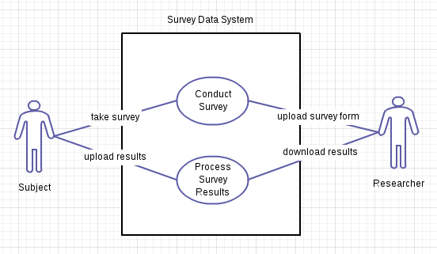

Source: [Brian High, Github](https://github.com/brianhigh/data-workshop/blob/master/images/research_survey_data_system.png), [Public Domain, CC0 1.0](http://creativecommons.org/publicdomain/zero/1.0/)

# Logical Design

- Abstract representation
- Data flows, entities, and relationships
- Inputs and outputs
- Graphical modeling:
- [Data Flow Diagram (DFD)](http://en.wikipedia.org/wiki/Data_flow_diagram)
- [Entity Relationship Diagram (ERD)](http://en.wikipedia.org/wiki/Entity%E2%80%93relationship_model)

Source: [Wikipedia](http://en.wikipedia.org/wiki/Systems_design#Logical_design), [CC BY-SA 3.0](http://en.wikipedia.org/wiki/Wikipedia:Text_of_Creative_Commons_Attribution-ShareAlike_3.0_Unported_License)

[Entity Relationship Diagram](http://en.wikipedia.org/wiki/Entity%E2%80%93relationship_model)

- **Artist** *performs song*

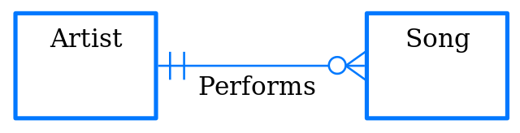

Source: [Bignose, Wikimedia](http://commons.wikimedia.org/wiki/File:ERD-artist-performs-song.svg), [Public Domain](http://en.wikipedia.org/wiki/Public_domain)

# Logical Design: Diagrams

Several examples of these diagrams can be found in [Systems Analysis and Design](https://github.com/brianhigh/data-workshop/blob/master/Systems_Analysis_and_Design.md).

This [tutorial](https://github.com/brianhigh/data-workshop/blob/master/Systems_Analysis_and_Design.md)<sup>1</sup> ([PDF](https://canvas.uw.edu/courses/951183/modules/items/5479924), [HTML](https://canvas.uw.edu/courses/951183/modules/items/5479962), [MP4](https://canvas.uw.edu/courses/951183/modules/items/5479995)) provides several examples from a fictitious public health research study.

1. See also: *[Data Management](https://canvas.uw.edu/courses/951183/modules)*, UW Canvas.

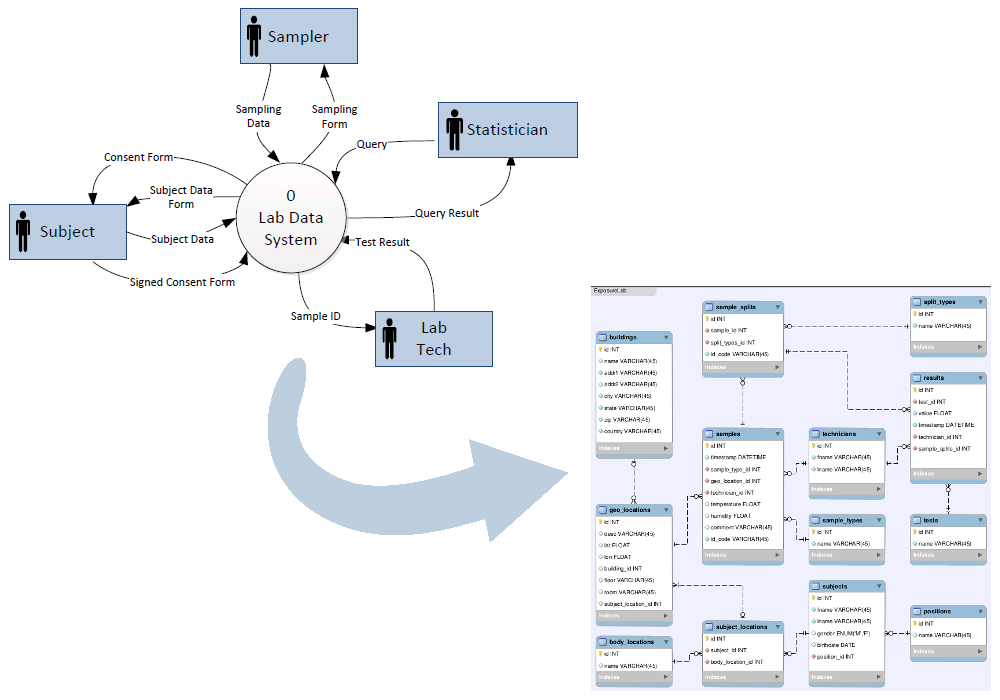

Source: [Brian High, Github](https://github.com/brianhigh/data-workshop/blob/master/images/analysis_and_design.png), [Public Domain, CC0 1.0](http://creativecommons.org/publicdomain/zero/1.0/)

# Decision Analysis

[Decision analysis](http://en.wikipedia.org/wiki/Decision_analysis) involves … * Presentation of alternatives: * What to buy or build? * Evaluation of alternatives: * Assess the “pros and cons” * Compare against requirements * Make a recommendation to stakeholders * Get a decision from stakeholders

Source: [Wikipedia](http://en.wikipedia.org/wiki/Decision_analysis), [CC BY-SA 3.0](http://en.wikipedia.org/wiki/Wikipedia:Text_of_Creative_Commons_Attribution-ShareAlike_3.0_Unported_License)